# Organisation des données et opérations sur des tableaux

Serge-Étienne Parent

2020-01-21

## Plan :bug:

1. Les tableaux et leur organisation
2. Manipuler des données en mode tidyverse
3. Combiner des tableaux
4. Opérations sur les tableaux
5. Fermeture

## Objectifs spécifiques

À la fin de ce chapitre, vous

- comprendrez les règles guidant la création et la gestion des tableaux,
- saurez importer et exporter des données et
- saurez effectuer des opérations en cascade avec le module tidyverse, dont
  - des filtres sur les lignes,
  - des sélections de colonnes,
  - des sommaires statistiques et
  - des jointures entre tableaux.

## 1. Les tableaux et leur organisation

## Les données

> Définition: valeur associée à une variable.

| Variable | Type | Valeur |
| --- | --- | --- |
| Taille | `numeric` | 1.71 m |
| Couleur | `factor`, `character` | “Rouge” |
| Infecté | `logical` | TRUE |
| Date | `Date` | “2019-01-25” |

```r
class(TRUE)
```

```
## [1] "logical"
```

## Collections de données (1/3)

**Vecteurs**

```r
c(2, 5, 1, 7, 4, 3)
```

```
## [1] 2 5 1 7 4 3
```

**Matrice**

```r
matrix(c(2, 5, 1, 7, 4, 3), ncol = 3)
```

```
##      [,1] [,2] [,3]
## [1,]    2    1    4
## [2,]    5    7    3
```

## Collections de données (2/3)

**Tableaux**

```r
data.frame(Station = c(1, 1, 2, 2, 3, 3),
           A = c(2, 5, 1, 7, 4, 3),
           B = c(5, 6, 8, 2, 6, 1))
```

```
##   Station A B
## 1       1 2 5
## 2       1 5 6
## 3       2 1 8
## 4       2 7 2
## 5       3 4 6
## 6       3 3 1
```

## Collections de données (3/3)

**Ensemble de tableaux (bases de données)**

```r
data.frame(Station = c(1, 1, 2, 2, 3, 3),
           A = c(2, 5, 1, 7, 4, 3),
           B = c(5, 6, 8, 2, 6, 1))
```

```
##   Station A B
## 1       1 2 5
## 2       1 5 6
## 3       2 1 8
## 4       2 7 2
## 5       3 4 6
## 6       3 3 1
```

```r
data.frame(Station = c(1, 2, 3),
           Lon = c(-71.15, -72.45, -70.81),
           Lat = c(46.21, 45.60, 45.76))
```

```
##   Station    Lon   Lat
## 1       1 -71.15 46.21
## 2       2 -72.45 45.60
## 3       3 -70.81 45.76
```

## Tableaux

- Organisation de données en deux dimensions, comportant des lignes et des colonnes.
- Une collection de vecteurs de même longueur, chaque vecteur représentant une variable de même type.

Dans R, format `data.frame` et `tibble`.

## Tidyverse

- tidyr: organiser les tableaux (format long, format large)
- tibble: format de tableau moderne
- dplyr: manipuler les tableaux (séléction, filtres)
- readr: importer et exporter des tableaux
- ggplot2: effectuer des graphiques (prochain cours)

```r
library("tidyverse")
```

## Tableaux: règle 1

- Une ligne = Une observation
- Une colonne = Une variable
- Une cellule = Une valeur (ou une sous-collection de valeurs)

## Ce tableau respecte-t-il la règle 1?

On consigne les rendements pour trois traitements.

| Site | Traitement A | Traitement B | Traitement C |
| --- | --- | --- | --- |
| Sainte-Souris | 4.1 | 8.2 | 6.8 |
| Sainte-Fourmi | 5.8 | 5.9 | NA |
| Saint-Ours | 2.9 | 3.4 | 4.6 |

## Mieux vaut ce format

| Site | Traitement | Rendement |
| --- | --- | --- |
| Sainte-Souris | A | 4.1 |
| Sainte-Souris | B | 8.2 |
| Sainte-Souris | C | 6.8 |
| Sainte-Fourmi | A | 5.8 |
| Sainte-Fourmi | B | 5.9 |
| Sainte-Fourmi | C | NA |
| Saint-Ours | A | 2.9 |
| Saint-Ours | B | 3.4 |
| Saint-Ours | C | 4.6 |

## Tableaux: règle 2

Un tableau par unité observationnelle: ne pas répéter les informations.

```r
data <- tibble(Station = c(1, 1, 2, 2, 3, 3),
               A = c(2, 5, 1, 7, 4, 3),
               B = c(5, 6, 8, 2, 6, 1),
               Lon = c(-71.15, -71.15, -72.45, -72.45, -70.81, -70.81),
               Lat = c(46.21, 46.21, 45.60, 45.60, 45.76, 45.76))
data
```

```
## # A tibble: 6 x 5
##   Station     A     B   Lon   Lat
##     <dbl> <dbl> <dbl> <dbl> <dbl>
## 1       1     2     5 -71.2  46.2
## 2       1     5     6 -71.2  46.2
## 3       2     1     8 -72.4  45.6
## 4       2     7     2 -72.4  45.6
## 5       3     4     6 -70.8  45.8
## 6       3     3     1 -70.8  45.8
```

```r
tibble(Station = c(1, 1, 2, 2, 3, 3),
       A = c(2, 5, 1, 7, 4, 3),
       B = c(5, 6, 8, 2, 6, 1))
```

```
## # A tibble: 6 x 3
##   Station     A     B
##     <dbl> <dbl> <dbl>
## 1       1     2     5
## 2       1     5     6
## 3       2     1     8
## 4       2     7     2
## 5       3     4     6
## 6       3     3     1
```

```r
tibble(Station = c(1, 2, 3),
       Lon = c(-71.15, -72.45, -70.81),
       Lat = c(46.21, 45.60, 45.76))
```

```
## # A tibble: 3 x 3
##   Station   Lon   Lat
##     <dbl> <dbl> <dbl>
## 1       1 -71.2  46.2
## 2       2 -72.4  45.6
## 3       3 -70.8  45.8
```

## Tableaux: règle 3

Ne pas bousiller les données:

- Ajouter des commentaires dans des cellules
- Inscription non systématiques
- Inclure des notes dans un tableau
- Ajouter des sommaires
- Inclure une hiérarchie dans le entêtes

–> Contre-exemple (iris.xlsx)

## Formats de tableau

- xls, xlsx ou ods: ok comme outil de calcul, mais pas pour entreposer des données
- csv: texte brut (encodage recomandé: UTF-8)
- SQL: Structured Query Language, pour les bases de données

–> Exemple csv (chicoute.csv)

## 2. Manipuler des données en mode tidyverse

## Importer vos données dans voter session de travail

Utilsier les fonction du module readr, ou bien la fonction de base `read.csv()`.

```r
library("tidyverse")
chicoute <- read_csv2(file = "../../data/chicoute.csv")
```

```
## Using ',' as decimal and '.' as grouping mark. Use read_delim() for more control.
```

## Fonctions de base sur les tableaux

```r
head(chicoute, n = 6)
```

```
## # A tibble: 6 x 31
##      ID CodeTourbiere Ordre  Site Traitement DemiParcelle SousTraitement
##   <dbl> <chr>         <chr> <dbl> <chr>      <chr>        <chr>
## 1     1 BEAU          A         1 <NA>       <NA>         <NA>
## 2     2 BEAU          A         2 <NA>       <NA>         <NA>
## 3     3 BEAU          A         3 <NA>       <NA>         <NA>
## 4     4 BEAU          A         4 <NA>       <NA>         <NA>
## 5     5 BEAU          A         5 <NA>       <NA>         <NA>
## 6     6 BP            H         1 <NA>       <NA>         <NA>
## # … with 24 more variables: Latitude_m <dbl>, Longitude_m <dbl>,
## #   Rendement_g_5m2 <dbl>, TotalRamet_nombre_m2 <dbl>,
## #   TotalVegetatif_nombre_m2 <dbl>, TotalFloral_nombre_m2 <dbl>,
## #   TotalMale_nombre_m2 <dbl>, TotalFemelle_nombre_m2 <dbl>,
## #   FemelleFruit_nombre_m2 <dbl>, FemelleAvorte_nombre_m2 <dbl>,
## #   SterileFleur_nombre_m2 <dbl>, C_pourc <dbl>, N_pourc <dbl>, P_pourc <dbl>,
## #   K_pourc <dbl>, Ca_pourc <dbl>, Mg_pourc <dbl>, S_pourc <dbl>,
## #   B_pourc <dbl>, Cu_pourc <dbl>, Zn_pourc <dbl>, Mn_pourc <dbl>,
## #   Fe_pourc <dbl>, Al_pourc <dbl>
```

```r
str(chicoute) # ou glimpse()
```

```
## Classes 'spec_tbl_df', 'tbl_df', 'tbl' and 'data.frame': 90 obs. of  31 variables:
##  $ ID                      : num  1 2 3 4 5 6 7 8 9 10 ...
##  $ CodeTourbiere           : chr  "BEAU" "BEAU" "BEAU" "BEAU" ...
##  $ Ordre                   : chr  "A" "A" "A" "A" ...
##  $ Site                    : num  1 2 3 4 5 1 2 3 4 5 ...
##  $ Traitement              : chr  NA NA NA NA ...
##  $ DemiParcelle            : chr  NA NA NA NA ...
##  $ SousTraitement          : chr  NA NA NA NA ...
##  $ Latitude_m              : num  5702454 5702452 5702461 5702453 5702445 ...
##  $ Longitude_m             : num  490627 490634 490638 490647 490654 ...
##  $ Rendement_g_5m2         : num  NA NA NA NA NA NA NA NA NA NA ...
##  $ TotalRamet_nombre_m2    : num  453 461 652 591 564 ...
##  $ TotalVegetatif_nombre_m2: num  256 334 581 441 365 ...
##  $ TotalFloral_nombre_m2   : num  197.4 127.3 71.3 150.2 198.6 ...
##  $ TotalMale_nombre_m2     : num  10.19 0 1.27 104.41 92.95 ...
##  $ TotalFemelle_nombre_m2  : num  187.2 124.8 70 45.8 105.7 ...
##  $ FemelleFruit_nombre_m2  : num  157.9 71.3 48.4 39.5 94.2 ...
##  $ FemelleAvorte_nombre_m2 : num  8.91 14.01 19.1 3.82 2.55 ...
##  $ SterileFleur_nombre_m2  : num  0 2.55 0 0 0 ...
##  $ C_pourc                 : num  51.5 51.3 50.5 51.6 53.8 ...
##  $ N_pourc                 : num  1.73 2.18 2.12 1.95 2.04 ...
##  $ P_pourc                 : num  0.1083 0.0985 0.0708 0.0909 0.1152 ...
##  $ K_pourc                 : num  1.213 1.215 1.049 1.192 0.947 ...
##  $ Ca_pourc                : num  0.435 0.337 0.373 0.5 0.333 ...
##  $ Mg_pourc                : num  0.47 0.439 0.42 0.388 0.472 ...
##  $ S_pourc                 : num  0.0977 0.0996 0.1044 0.0922 0.1062 ...
##  $ B_pourc                 : num  0.00258 0.00258 0.00258 0.00258 0.00258 ...
##  $ Cu_pourc                : num  1.75e-04 4.07e-04 3.70e-05 9.29e-05 3.70e-05 ...
##  $ Zn_pourc                : num  0.0047 0.00729 0.00713 0.0055 0.0051 ...
##  $ Mn_pourc                : num  0.1006 0.0783 0.0722 0.031 0.0345 ...
##  $ Fe_pourc                : num  0.0133 0.0148 0.0148 0.0135 0.012 ...
##  $ Al_pourc                : num  0.001558 0.00189 0.001602 0.000895 0.001021 ...
##  - attr(*, "spec")=
##   .. cols(
##   ..   ID = col_double(),
##   ..   CodeTourbiere = col_character(),
##   ..   Ordre = col_character(),
##   ..   Site = col_double(),
##   ..   Traitement = col_character(),
##   ..   DemiParcelle = col_character(),
```

[output cut: 11 more lines]

```
##   ..   SterileFleur_nombre_m2 = col_double(),
##   ..   C_pourc = col_double(),
##   ..   N_pourc = col_double(),
##   ..   P_pourc = col_double(),
##   ..   K_pourc = col_double(),
##   ..   Ca_pourc = col_double(),
##   ..   Mg_pourc = col_double(),
##   ..   S_pourc = col_double(),
##   ..   B_pourc = col_double(),
##   ..   Cu_pourc = col_double(),
##   ..   Zn_pourc = col_double(),
##   ..   Mn_pourc = col_double(),
##   ..   Fe_pourc = col_double(),
##   ..   Al_pourc = col_double()
##   .. )
```

```r
summary(chicoute)
```

```
##        ID        CodeTourbiere         Ordre                Site
##  Min.   : 1.00   Length:90          Length:90          Min.   : 1.000
##  1st Qu.:23.25   Class :character   Class :character   1st Qu.: 2.000
##  Median :45.50   Mode  :character   Mode  :character   Median : 4.000
##  Mean   :45.50                                         Mean   : 6.333
##  3rd Qu.:67.75                                         3rd Qu.: 9.000
##  Max.   :90.00                                         Max.   :20.000
##
##   Traitement        DemiParcelle       SousTraitement       Latitude_m
##  Length:90          Length:90          Length:90          Min.   :5695688
##  Class :character   Class :character   Class :character   1st Qu.:5701868
##  Mode  :character   Mode  :character   Mode  :character   Median :5702129
##                                                           Mean   :5701840
##                                                           3rd Qu.:5702537
##                                                           Max.   :5706394
##
##   Longitude_m     Rendement_g_5m2  TotalRamet_nombre_m2
##  Min.   :459873   Min.   : 0.000   Min.   : 40.74
##  1st Qu.:485927   1st Qu.: 0.000   1st Qu.:122.70
##  Median :486500   Median : 0.945   Median :212.92
##  Mean   :485296   Mean   :13.329   Mean   :251.26
##  3rd Qu.:486545   3rd Qu.:15.628   3rd Qu.:347.80
##  Max.   :491955   Max.   :72.435   Max.   :651.90
##                   NA's   :50
##  TotalVegetatif_nombre_m2 TotalFloral_nombre_m2 TotalMale_nombre_m2
##  Min.   : 22.92           Min.   :  4.80        Min.   :  0.00
##  1st Qu.: 86.26           1st Qu.: 22.92        1st Qu.:  3.30
##  Median :161.25           Median : 43.00        Median : 15.28
##  Mean   :199.02           Mean   : 52.08        Mean   : 24.40
##  3rd Qu.:263.78           3rd Qu.: 69.52        3rd Qu.: 36.51
##  Max.   :580.60           Max.   :198.62        Max.   :104.41
##  NA's   :4                NA's   :4             NA's   :4
##  TotalFemelle_nombre_m2 FemelleFruit_nombre_m2 FemelleAvorte_nombre_m2
##  Min.   :  2.546        Min.   :  0.400        Min.   : 0.000
##  1st Qu.: 10.339        1st Qu.:  7.639        1st Qu.: 1.273
##  Median : 17.189        Median : 11.459        Median : 3.073
##  Mean   : 27.528        Mean   : 19.966        Mean   : 8.494
##  3rd Qu.: 31.958        3rd Qu.: 22.830        3rd Qu.:10.139
##  Max.   :187.166        Max.   :157.881        Max.   :76.800
##  NA's   :4              NA's   :18             NA's   :4
```

[output cut: 17 more lines]

```
##  Min.   :0.001820   Min.   :0.0000370   Min.   :0.003267   Min.   :0.002298
##  1st Qu.:0.002563   1st Qu.:0.0000370   1st Qu.:0.005493   1st Qu.:0.012048
##  Median :0.003181   Median :0.0002132   Median :0.006320   Median :0.027872
##  Mean   :0.003091   Mean   :0.0004090   Mean   :0.006662   Mean   :0.033452
##  3rd Qu.:0.003503   3rd Qu.:0.0004606   3rd Qu.:0.007194   3rd Qu.:0.050051
##  Max.   :0.004167   Max.   :0.0042487   Max.   :0.016240   Max.   :0.104450
##
##     Fe_pourc           Al_pourc
##  Min.   :0.009132   Min.   :0.0008953
##  1st Qu.:0.010907   1st Qu.:0.0019199
##  Median :0.014254   Median :0.0023617
##  Mean   :0.015149   Mean   :0.0026950
##  3rd Qu.:0.017271   3rd Qu.:0.0033389
##  Max.   :0.052065   Max.   :0.0093337
##
```

```r
names(chicoute) # ou colnames
```

```
##  [1] "ID"                       "CodeTourbiere"
##  [3] "Ordre"                    "Site"
##  [5] "Traitement"               "DemiParcelle"
##  [7] "SousTraitement"           "Latitude_m"
##  [9] "Longitude_m"              "Rendement_g_5m2"
## [11] "TotalRamet_nombre_m2"     "TotalVegetatif_nombre_m2"
## [13] "TotalFloral_nombre_m2"    "TotalMale_nombre_m2"
## [15] "TotalFemelle_nombre_m2"   "FemelleFruit_nombre_m2"
## [17] "FemelleAvorte_nombre_m2"  "SterileFleur_nombre_m2"
## [19] "C_pourc"                  "N_pourc"
## [21] "P_pourc"                  "K_pourc"
## [23] "Ca_pourc"                 "Mg_pourc"
## [25] "S_pourc"                  "B_pourc"
## [27] "Cu_pourc"                 "Zn_pourc"
## [29] "Mn_pourc"                 "Fe_pourc"
## [31] "Al_pourc"
```

```r
dim(chicoute) # ncol, nrow
```

```
## [1] 90 31
```

```r
skimr::skim(chicoute)
```

Data summary

| Name | chicoute |
| --- | --- |
| Number of rows | 90 |
| Number of columns | 31 |
| _______________________ |  |
| Column type frequency: |  |
| character | 5 |
| numeric | 26 |
| ________________________ |  |
| Group variables | None |

**Variable type: character**

| skim_variable | n_missing | complete_rate | min | max | empty | n_unique | whitespace |
| --- | --- | --- | --- | --- | --- | --- | --- |
| CodeTourbiere | 0 | 1.00 | 1 | 4 | 0 | 12 | 0 |
| Ordre | 0 | 1.00 | 1 | 2 | 0 | 20 | 0 |
| Traitement | 50 | 0.44 | 6 | 11 | 0 | 2 | 0 |
| DemiParcelle | 50 | 0.44 | 4 | 5 | 0 | 2 | 0 |
| SousTraitement | 50 | 0.44 | 1 | 7 | 0 | 3 | 0 |

**Variable type: numeric**

| skim_variable | n_missing | complete_rate | mean | sd | p0 | p25 | p50 | p75 | p100 | hist |
| --- | --- | --- | --- | --- | --- | --- | --- | --- | --- | --- |
| ID | 0 | 1.00 | 45.50 | 26.12 | 1.00 | 23.25 | 45.50 | 67.75 | 90.00 | ▇▇▇▇▇ |
| Site | 0 | 1.00 | 6.33 | 5.49 | 1.00 | 2.00 | 4.00 | 9.00 | 20.00 | ▇▃▁▁▁ |
| Latitude_m | 0 | 1.00 | 5701839.86 | 1915.50 | 5695688.00 | 5701868.50 | 5702129.00 | 5702537.00 | 5706394.00 | ▁▂▅▇▁ |
| Longitude_m | 0 | 1.00 | 485295.54 | 6452.33 | 459873.00 | 485927.00 | 486500.00 | 486544.75 | 491955.00 | ▁▁▁▂▇ |
| Rendement_g_5m2 | 50 | 0.44 | 13.33 | 21.56 | 0.00 | 0.00 | 0.94 | 15.63 | 72.44 | ▇▁▁▁▁ |
| TotalRamet_nombre_m2 | 0 | 1.00 | 251.26 | 156.06 | 40.74 | 122.70 | 212.92 | 347.80 | 651.90 | ▇▇▃▂▂ |
| TotalVegetatif_nombre_m2 | 4 | 0.96 | 199.02 | 139.13 | 22.92 | 86.26 | 161.25 | 263.78 | 580.60 | ▇▇▂▂▁ |
| TotalFloral_nombre_m2 | 4 | 0.96 | 52.08 | 40.41 | 4.80 | 22.92 | 43.00 | 69.52 | 198.62 | ▇▅▂▁▁ |
| TotalMale_nombre_m2 | 4 | 0.96 | 24.40 | 26.87 | 0.00 | 3.30 | 15.28 | 36.51 | 104.41 | ▇▂▂▁▁ |
| TotalFemelle_nombre_m2 | 4 | 0.96 | 27.53 | 29.83 | 2.55 | 10.34 | 17.19 | 31.96 | 187.17 | ▇▁▁▁▁ |
| FemelleFruit_nombre_m2 | 18 | 0.80 | 19.97 | 23.79 | 0.40 | 7.64 | 11.46 | 22.83 | 157.88 | ▇▂▁▁▁ |
| FemelleAvorte_nombre_m2 | 4 | 0.96 | 8.49 | 14.52 | 0.00 | 1.27 | 3.07 | 10.14 | 76.80 | ▇▁▁▁▁ |
| SterileFleur_nombre_m2 | 4 | 0.96 | 0.26 | 0.71 | 0.00 | 0.00 | 0.00 | 0.00 | 3.82 | ▇▁▁▁▁ |
| C_pourc | 0 | 1.00 | 50.28 | 1.61 | 46.72 | 49.14 | 50.45 | 51.58 | 53.83 | ▃▆▅▇▁ |
| N_pourc | 0 | 1.00 | 2.20 | 0.40 | 1.53 | 1.89 | 2.12 | 2.58 | 3.10 | ▃▇▃▃▂ |
| P_pourc | 0 | 1.00 | 0.14 | 0.04 | 0.07 | 0.12 | 0.14 | 0.16 | 0.23 | ▃▆▇▂▂ |
| K_pourc | 0 | 1.00 | 0.89 | 0.27 | 0.35 | 0.69 | 0.86 | 1.13 | 1.54 | ▃▇▇▇▁ |
| Ca_pourc | 0 | 1.00 | 0.39 | 0.10 | 0.19 | 0.32 | 0.37 | 0.44 | 0.88 | ▅▇▂▁▁ |
| Mg_pourc | 0 | 1.00 | 0.50 | 0.08 | 0.36 | 0.45 | 0.48 | 0.52 | 0.86 | ▇▇▂▁▁ |
| S_pourc | 0 | 1.00 | 0.13 | 0.04 | 0.07 | 0.11 | 0.13 | 0.14 | 0.28 | ▅▇▂▁▁ |
| B_pourc | 0 | 1.00 | 0.00 | 0.00 | 0.00 | 0.00 | 0.00 | 0.00 | 0.00 | ▂▅▃▇▃ |
| Cu_pourc | 0 | 1.00 | 0.00 | 0.00 | 0.00 | 0.00 | 0.00 | 0.00 | 0.00 | ▇▁▁▁▁ |
| Zn_pourc | 0 | 1.00 | 0.01 | 0.00 | 0.00 | 0.01 | 0.01 | 0.01 | 0.02 | ▇▇▂▁▁ |
| Mn_pourc | 0 | 1.00 | 0.03 | 0.03 | 0.00 | 0.01 | 0.03 | 0.05 | 0.10 | ▇▅▃▂▁ |
| Fe_pourc | 0 | 1.00 | 0.02 | 0.01 | 0.01 | 0.01 | 0.01 | 0.02 | 0.05 | ▇▂▁▁▁ |
| Al_pourc | 0 | 1.00 | 0.00 | 0.00 | 0.00 | 0.00 | 0.00 | 0.00 | 0.01 | ▇▅▁▁▁ |

## Sélection et filtre

- Sélectionner: colonnes
- Filtrer: les lignes

## Sélectionner

Par indice

```r
chicoute[, c(1, 4, 13)]
```

```
## # A tibble: 90 x 3
##       ID  Site TotalFloral_nombre_m2
##    <dbl> <dbl>                 <dbl>
##  1     1     1                 197.
##  2     2     2                 127.
##  3     3     3                  71.3
##  4     4     4                 150.
##  5     5     5                 199.
##  6     6     1                  28.0
##  7     7     2                  45.8
##  8     8     3                 108.
##  9     9     4                  70.0
## 10    10     5                  49.7
## # … with 80 more rows
```

## Sélectionner

Par nom (une seule colonne), avec `$`

```r
chicoute$Rendement_g_5m2 # s'il y a des caractères irrégulies dans le nom, chicoute$`Rendement g/5m2`
```

```
##  [1]        NA        NA        NA        NA        NA        NA        NA
##  [8]        NA        NA        NA  0.000000  0.000000  0.000000  0.000000
## [15]  0.000000  0.000000  0.000000  0.380000  0.000000  0.574000  0.000000
## [22]  0.000000  0.000000  0.000000  0.000000  0.000000  0.000000  0.000000
## [29]  0.000000  0.000000        NA        NA        NA        NA        NA
## [36]        NA        NA        NA        NA        NA        NA        NA
## [43]        NA        NA        NA        NA        NA        NA        NA
## [50]        NA        NA        NA        NA        NA        NA        NA
## [57]        NA        NA        NA        NA        NA        NA        NA
## [64]        NA        NA 63.989625 72.435183  6.418000  8.696253 55.583192
## [71] 48.954573 54.067095 62.320034  6.064000  1.316000  3.982000  2.914000
## [78] 28.709263 34.640063 21.109928 23.057676 12.440253 13.800573  5.188000
## [85]  6.500800        NA        NA        NA        NA        NA
```

## Sélectionner

Un vecteur de noms

```r
chicoute[c("Site", "Latitude_m", "Longitude_m")] # ou bien chicoute[, c("Site", "Latitude_m", "Longitude_m")]
```

```
## # A tibble: 90 x 3
##     Site Latitude_m Longitude_m
##    <dbl>      <dbl>       <dbl>
##  1     1    5702454      490627
##  2     2    5702452      490634
##  3     3    5702461      490638
##  4     4    5702453      490647
##  5     5    5702445      490654
##  6     1    5706394      484865
##  7     2    5706307      484054
##  8     3    5702280      484742
##  9     4    5706324      484761
## 10     5    5706364      484780
## # … with 80 more rows
```

## Sélectionner

Avec le symvol *pipe*, `%>%` (raccourci: Ctrl + Alt + M), qui se lit comme *puis*.

```r
chicoute %>%
  select(Site, Latitude_m, Longitude_m) # ou siplement select
```

```
## # A tibble: 90 x 3
##     Site Latitude_m Longitude_m
##    <dbl>      <dbl>       <dbl>
##  1     1    5702454      490627
##  2     2    5702452      490634
##  3     3    5702461      490638
##  4     4    5702453      490647
##  5     5    5702445      490654
##  6     1    5706394      484865
##  7     2    5706307      484054
##  8     3    5702280      484742
##  9     4    5706324      484761
## 10     5    5706364      484780
## # … with 80 more rows
```

## Sélectionner avec `select`

Tableau, puis sélectionne les colonnes qui se terminent par *pourc*, puis présente-moi l’entête de 3

On peut utiliser des expressions.

```r
chicoute %>%
  select(ends_with("pourc")) %>%
  head(3)
```

```
## # A tibble: 3 x 13
##   C_pourc N_pourc P_pourc K_pourc Ca_pourc Mg_pourc S_pourc B_pourc Cu_pourc
##     <dbl>   <dbl>   <dbl>   <dbl>    <dbl>    <dbl>   <dbl>   <dbl>    <dbl>
## 1    51.5    1.72  0.108     1.21    0.435    0.470  0.0976 0.00258 0.000175
## 2    51.3    2.18  0.0985    1.22    0.337    0.439  0.0996 0.00258 0.000407
## 3    50.6    2.12  0.0708    1.05    0.373    0.420  0.104  0.00258 0.000037
## # … with 4 more variables: Zn_pourc <dbl>, Mn_pourc <dbl>, Fe_pourc <dbl>,
## #   Al_pourc <dbl>
```

… et travailler en négatif pour enlever.

```r
chicoute %>%
  select(-ends_with("pourc")) %>%
  head(3)
```

```
## # A tibble: 3 x 18
##      ID CodeTourbiere Ordre  Site Traitement DemiParcelle SousTraitement
##   <dbl> <chr>         <chr> <dbl> <chr>      <chr>        <chr>
## 1     1 BEAU          A         1 <NA>       <NA>         <NA>
## 2     2 BEAU          A         2 <NA>       <NA>         <NA>
## 3     3 BEAU          A         3 <NA>       <NA>         <NA>
## # … with 11 more variables: Latitude_m <dbl>, Longitude_m <dbl>,
## #   Rendement_g_5m2 <dbl>, TotalRamet_nombre_m2 <dbl>,
## #   TotalVegetatif_nombre_m2 <dbl>, TotalFloral_nombre_m2 <dbl>,
## #   TotalMale_nombre_m2 <dbl>, TotalFemelle_nombre_m2 <dbl>,
## #   FemelleFruit_nombre_m2 <dbl>, FemelleAvorte_nombre_m2 <dbl>,
## #   SterileFleur_nombre_m2 <dbl>
```

## Filtrer

- Utiliser des indices (`c(10, 21, 67)`) ou des opérations logiques (`==`, `!=`, `<=`, etc.).
- Les opérations logiques peuvent être combinées:
  - ET est `&`
  - OU est `|`

## Filtrer

Méthode classique

```r
chicoute[chicoute$CodeTourbiere == "BEAU", ]
```

```
## # A tibble: 5 x 31
##      ID CodeTourbiere Ordre  Site Traitement DemiParcelle SousTraitement
##   <dbl> <chr>         <chr> <dbl> <chr>      <chr>        <chr>
## 1     1 BEAU          A         1 <NA>       <NA>         <NA>
## 2     2 BEAU          A         2 <NA>       <NA>         <NA>
## 3     3 BEAU          A         3 <NA>       <NA>         <NA>
## 4     4 BEAU          A         4 <NA>       <NA>         <NA>
## 5     5 BEAU          A         5 <NA>       <NA>         <NA>
## # … with 24 more variables: Latitude_m <dbl>, Longitude_m <dbl>,
## #   Rendement_g_5m2 <dbl>, TotalRamet_nombre_m2 <dbl>,
## #   TotalVegetatif_nombre_m2 <dbl>, TotalFloral_nombre_m2 <dbl>,
## #   TotalMale_nombre_m2 <dbl>, TotalFemelle_nombre_m2 <dbl>,
## #   FemelleFruit_nombre_m2 <dbl>, FemelleAvorte_nombre_m2 <dbl>,
## #   SterileFleur_nombre_m2 <dbl>, C_pourc <dbl>, N_pourc <dbl>, P_pourc <dbl>,
## #   K_pourc <dbl>, Ca_pourc <dbl>, Mg_pourc <dbl>, S_pourc <dbl>,
## #   B_pourc <dbl>, Cu_pourc <dbl>, Zn_pourc <dbl>, Mn_pourc <dbl>,
## #   Fe_pourc <dbl>, Al_pourc <dbl>
```

## Filtrer

Méthode tidyverse

```r
chicoute %>%
  filter(CodeTourbiere == "BEAU")
```

```
## # A tibble: 5 x 31
##      ID CodeTourbiere Ordre  Site Traitement DemiParcelle SousTraitement
##   <dbl> <chr>         <chr> <dbl> <chr>      <chr>        <chr>
## 1     1 BEAU          A         1 <NA>       <NA>         <NA>
## 2     2 BEAU          A         2 <NA>       <NA>         <NA>
## 3     3 BEAU          A         3 <NA>       <NA>         <NA>
## 4     4 BEAU          A         4 <NA>       <NA>         <NA>
## 5     5 BEAU          A         5 <NA>       <NA>         <NA>
## # … with 24 more variables: Latitude_m <dbl>, Longitude_m <dbl>,
## #   Rendement_g_5m2 <dbl>, TotalRamet_nombre_m2 <dbl>,
## #   TotalVegetatif_nombre_m2 <dbl>, TotalFloral_nombre_m2 <dbl>,
## #   TotalMale_nombre_m2 <dbl>, TotalFemelle_nombre_m2 <dbl>,
## #   FemelleFruit_nombre_m2 <dbl>, FemelleAvorte_nombre_m2 <dbl>,
## #   SterileFleur_nombre_m2 <dbl>, C_pourc <dbl>, N_pourc <dbl>, P_pourc <dbl>,
## #   K_pourc <dbl>, Ca_pourc <dbl>, Mg_pourc <dbl>, S_pourc <dbl>,
## #   B_pourc <dbl>, Cu_pourc <dbl>, Zn_pourc <dbl>, Mn_pourc <dbl>,
## #   Fe_pourc <dbl>, Al_pourc <dbl>
```

## Opérations combinées

Remarquez `%in%`, nouvel oprateur logique, qui signifie *`==` à l’un de …*.

```r
chicoute %>%
  filter(C_pourc < 50 & CodeTourbiere %in% c("BEAU", "MB", "WTP")) %>%
  select(contains("pourc"))
```

```
## # A tibble: 5 x 13
##   C_pourc N_pourc P_pourc K_pourc Ca_pourc Mg_pourc S_pourc B_pourc Cu_pourc
##     <dbl>   <dbl>   <dbl>   <dbl>    <dbl>    <dbl>   <dbl>   <dbl>    <dbl>
## 1    48.2    1.98  0.0892   0.648    0.496    0.611   0.184 0.00328 0.000197
## 2    48.0    1.72  0.0760   0.557    0.456    0.758   0.123 0.00328 0.000193
## 3    47.3    1.63  0.0756   0.507    0.521    0.862   0.130 0.00328 0.000341
## 4    47.8    1.80  0.0799   0.465    0.460    0.706   0.125 0.00328 0.000341
## 5    47.7    1.81  0.0848   0.713    0.517    0.565   0.115 0.00328 0.000170
## # … with 4 more variables: Zn_pourc <dbl>, Mn_pourc <dbl>, Fe_pourc <dbl>,
## #   Al_pourc <dbl>
```

## Du format large au format long

Les % en une seule variable? Utiliser `pivot_longer()`. Avant d’utiliser gather, assurez-vous que chaque ligne ait un identifiant unique.

```r
chicoute_long <- chicoute %>%
  select(CodeTourbiere, N_pourc, P_pourc, K_pourc) %>%
  mutate(ID = 1:nrow(.)) %>% # mutate ajoute une colonne au tableau
  pivot_longer(names_to = "element", values_to = "concentration", cols = c(-CodeTourbiere, -ID))
chicoute_long %>% sample_n(10)
```

```
## # A tibble: 10 x 4
##    CodeTourbiere    ID element concentration
##    <chr>         <int> <chr>           <dbl>
##  1 1                73 K_pourc         0.752
##  2 2                22 K_pourc         1.22
##  3 2                14 P_pourc         0.207
##  4 2                26 K_pourc         1.34
##  5 1                78 N_pourc         2.31
##  6 1                75 P_pourc         0.132
##  7 BP                6 N_pourc         2.13
##  8 1                83 P_pourc         0.132
##  9 NTP              55 K_pourc         0.419
## 10 MB               31 P_pourc         0.128
```

## Du format long au format large

Pour l’opération inverse, utiliser `pivot_wider()`. L’identifiant unique sert à retracer la ligne!

```r
chicoute_large <- chicoute_long %>%
  pivot_wider(names_from = "element", values_from = "concentration") %>%
  select(-ID) # enlever l'identifiant unique
chicoute_large %>% sample_n(10)
```

```
## # A tibble: 10 x 4
##    CodeTourbiere N_pourc P_pourc K_pourc
##    <chr>           <dbl>   <dbl>   <dbl>
##  1 BP               2.06  0.162    0.824
##  2 2                2.86  0.202    1.18
##  3 1                2.55  0.132    0.684
##  4 BS2              2.62  0.108    0.632
##  5 BEAU             1.72  0.108    1.21
##  6 BEAU             2.12  0.0708   1.05
##  7 1                2.25  0.168    0.752
##  8 1                2.77  0.206    1.18
##  9 2                3.10  0.207    1.33
## 10 2                2.78  0.167    0.831
```

## 3. Combiner des tableaux

## Combiner des tableaux

J’ai des informations supplémentaires à propos des tourbières (colonne `CodeTourbiere`). Comment les combinées avec l’information existante?

Par exemple, `chicoute %>% left_join(tourbieres, by = "CodeTourbiere")` collera sur le tableau `chicoute` seulement les infos des tourbières dont le code est présent dans le tableau `chicoute`.

## left_join

`left_join(x, y)` ou `x %>% left_join(y)`: colle y à x seulement ce qui dans y correspond à ce que l’on trouve dans x.

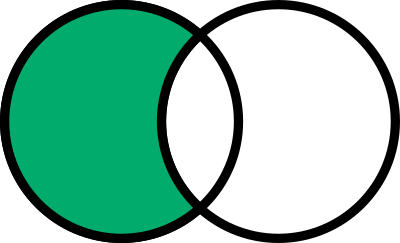

## right_join

Idem `left_join`, mais l’inverse:

`right_join(x, y)` ou `x %>% right_join(y)`: colle y à x seulement ce qui dans x correspond à ce que l’on trouve dans y.

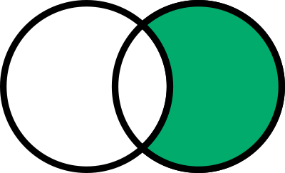

## inner_join

`inner_join(x, y)` colle x et y en excluant les lignes où au moins une variable de joint est absente dans x et y.

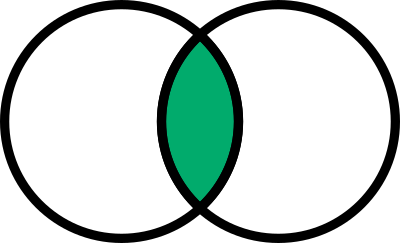

## full_join

`full_join(x, y)` garde toutes les lignes et les colonnes de x et y.

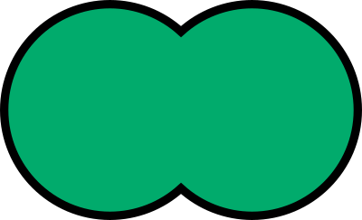

## Exemple

```r
tourbieres <- read_csv2("../../data/chicoute_tourbieres.csv")
```

```
## Using ',' as decimal and '.' as grouping mark. Use read_delim() for more control.
```

```r
tourbieres %>%
  sample_n(10)
```

```
## # A tibble: 10 x 4
##    Tourbiere               CodeTourbiere Type        TypeCulture
##    <chr>                   <chr>         <chr>       <chr>
##  1 Sphaigne (BS2F)         BS2           validation  cultive sec
##  2 Beaulieu                BEAU          calibration naturel
##  3 Sphaigne (BS2F)         1             calibration naturel
##  4 North Est of Smelt Pond NESP          calibration naturel
##  5 North of Blue Moon      NBM           calibration naturel
##  6 Mannys Brook            MB            calibration naturel
##  7 West of Trout Pond      WTP           calibration naturel
##  8 South of Smelt Pond     SSP           calibration naturel
##  9 Middle Bay Road         MR            calibration naturel
## 10 Lichen (BS2E)           2             validation  cultive sec
```

## Fusionner

```r
chicoute_merge <- chicoute %>%
  left_join(y = tourbieres, by = "CodeTourbiere")
chicoute_merge %>%
  #select(ID, CodeTourbiere, Site, Tourbiere) %>%
  sample_n(4)
```

```
## # A tibble: 4 x 34
##      ID CodeTourbiere Ordre  Site Traitement DemiParcelle SousTraitement
##   <dbl> <chr>         <chr> <dbl> <chr>      <chr>        <chr>
## 1    66 1             1         1 fertilisa… left         B
## 2    13 2             6        12 temoin     left         Control
## 3    14 2             6        12 temoin     right        B
## 4    86 WTP           E         1 <NA>       <NA>         <NA>
## # … with 27 more variables: Latitude_m <dbl>, Longitude_m <dbl>,
## #   Rendement_g_5m2 <dbl>, TotalRamet_nombre_m2 <dbl>,
## #   TotalVegetatif_nombre_m2 <dbl>, TotalFloral_nombre_m2 <dbl>,
## #   TotalMale_nombre_m2 <dbl>, TotalFemelle_nombre_m2 <dbl>,
## #   FemelleFruit_nombre_m2 <dbl>, FemelleAvorte_nombre_m2 <dbl>,
## #   SterileFleur_nombre_m2 <dbl>, C_pourc <dbl>, N_pourc <dbl>, P_pourc <dbl>,
## #   K_pourc <dbl>, Ca_pourc <dbl>, Mg_pourc <dbl>, S_pourc <dbl>,
## #   B_pourc <dbl>, Cu_pourc <dbl>, Zn_pourc <dbl>, Mn_pourc <dbl>,
## #   Fe_pourc <dbl>, Al_pourc <dbl>, Tourbiere <chr>, Type <chr>,
## #   TypeCulture <chr>
```

## 4. Opérations sur les tableaux

## Opérations sur les tableaux

Les colonnes des tableaux réagissent comme les vecteurs. On peut effectuer des opérations avec des vecteurs comme avec des scalaires.

```r
chicoute$C_pourc[1:10]
```

```
##  [1] 51.47 51.29 50.55 51.58 53.83 51.47 51.46 51.24 50.68 50.92
```

```r
chicoute$C_pourc[1:10] + 1
```

```
##  [1] 52.47 52.29 51.55 52.58 54.83 52.47 52.46 52.24 51.68 51.92
```

```r
chicoute$C_pourc[1:10] + 1:10
```

```
##  [1] 52.47 53.29 53.55 55.58 58.83 57.47 58.46 59.24 59.68 60.92
```

## Fonctions sommaires

En mode classique

```r
sum(chicoute$Rendement_g_5m2, na.rm = TRUE)
```

```
## [1] 533.1405
```

En mode tidyverse

```r
chicoute %>%
  pull(Rendement_g_5m2) %>% # pull extrait le vecteur, alors que select génère un tableau
  sum(na.rm = TRUE)
```

```
## [1] 533.1405
```

## Opérations sur les lignes et les colonnes

En mode classique avec apply

```r
apply(chicoute %>% select(contains("pourc")), MARGIN = 2, FUN = mean)
```

```
##      C_pourc      N_pourc      P_pourc      K_pourc     Ca_pourc     Mg_pourc
## 5.027911e+01 2.199411e+00 1.388959e-01 8.887000e-01 3.884391e-01 4.980142e-01
##      S_pourc      B_pourc     Cu_pourc     Zn_pourc     Mn_pourc     Fe_pourc
## 1.347177e-01 3.090922e-03 4.089891e-04 6.662155e-03 3.345239e-02 1.514885e-02
##     Al_pourc
## 2.694979e-03
```

## Opérations sur les lignes et les colonnes

En mode tidyverse, il existe une panoplie de solutions. Sur une seule colonne, on pourra utiliser `summarise`.

```r
chicoute %>%
  summarise(rendement = mean(Rendement_g_5m2, na.rm = TRUE))
```

```
## # A tibble: 1 x 1
##   rendement
##       <dbl>
## 1      13.3
```

Sur plusieurs colonnes, `summarise_all`.

```r
chicoute %>%
  select(contains("pourc")) %>%
  summarise_all(mean)
```

```
## # A tibble: 1 x 13
##   C_pourc N_pourc P_pourc K_pourc Ca_pourc Mg_pourc S_pourc B_pourc Cu_pourc
##     <dbl>   <dbl>   <dbl>   <dbl>    <dbl>    <dbl>   <dbl>   <dbl>    <dbl>
## 1    50.3    2.20   0.139   0.889    0.388    0.498   0.135 0.00309 0.000409
## # … with 4 more variables: Zn_pourc <dbl>, Mn_pourc <dbl>, Fe_pourc <dbl>,
## #   Al_pourc <dbl>
```

Ou, sur plusieurs lignes ou colonnes, j’en viens souvent à utiliser `apply` comme ceci.

```r
chicoute %>%
  select(contains("pourc")) %>%
  apply(., 2, mean)
```

```
##      C_pourc      N_pourc      P_pourc      K_pourc     Ca_pourc     Mg_pourc
## 5.027911e+01 2.199411e+00 1.388959e-01 8.887000e-01 3.884391e-01 4.980142e-01
##      S_pourc      B_pourc     Cu_pourc     Zn_pourc     Mn_pourc     Fe_pourc
## 1.347177e-01 3.090922e-03 4.089891e-04 6.662155e-03 3.345239e-02 1.514885e-02
##     Al_pourc
## 2.694979e-03
```

## Opération regroupées

Effectuer des opérations par groupe. Ici, j’effectue un sommaire de deux fonctions.

```r
chicoute %>%
  group_by(CodeTourbiere) %>%
  summarise(moyenne = mean(TotalFloral_nombre_m2, na.rm = TRUE),
            ecart_type = sd(TotalFloral_nombre_m2, na.rm = TRUE))
```

```
## # A tibble: 12 x 3
##    CodeTourbiere moyenne ecart_type
##    <chr>           <dbl>      <dbl>
##  1 1                72.1      32.7
##  2 2                37.1      32.9
##  3 BEAU            149.       53.2
##  4 BP               60.4      30.6
##  5 BS2              27.2      15.5
##  6 MB               64.7      40.8
##  7 MR               35.1      10.5
##  8 NBM              35.1      16.6
##  9 NESP             21.4       4.88
## 10 NTP              47.6      15.9
## 11 SSP              25.7      11.1
## 12 WTP              50.2      28.3
```

Les sommaires groupés avec plusuers colonnes.

```r
chicoute %>%
  group_by(CodeTourbiere) %>%
  select(N_pourc, P_pourc) %>%
  summarise_all(funs(mean, sd))
```

```
## # A tibble: 12 x 5
##    CodeTourbiere N_pourc_mean P_pourc_mean N_pourc_sd P_pourc_sd
##    <chr>                <dbl>        <dbl>      <dbl>      <dbl>
##  1 1                     2.26       0.156      0.250     0.0193
##  2 2                     2.76       0.181      0.178     0.0283
##  3 BEAU                  2.00       0.0967     0.179     0.0172
##  4 BP                    2.05       0.158      0.161     0.00625
##  5 BS2                   2.08       0.103      0.420     0.0218
##  6 MB                    2.15       0.109      0.114     0.0165
##  7 MR                    1.99       0.127      0.0802    0.0131
##  8 NBM                   2.01       0.127      0.310     0.0202
##  9 NESP                  1.76       0.135      0.149     0.0108
## 10 NTP                   1.83       0.0873     0.166     0.0103
## 11 SSP                   1.83       0.130      0.160     0.00383
## 12 WTP                   1.79       0.0811     0.132     0.00587
```

## Exercice

Espèces menacées, données issues de l’UICN ([distribuées par l’OCDE](https://stats.oecd.org/Index.aspx?DataSetCode=WILD_LIFE)).

```r
especes_menacees <- read_csv('../../data/WILD_LIFE_14012020030114795.csv') # données de UICN,
```

## Exercice

Ce cheminement comporte de nouvelles fonctions. Pouvez-vous identifier ce qu’il produira comme information?

```r
especes_menacees %>%
  filter(IUCN == 'CRITICAL') %>%
  select(Country, Value) %>%
  group_by(Country)  %>%
  summarise(n_critical_species = sum(Value)) %>%
  arrange(desc(n_critical_species)) %>%
  top_n(10)
```

```
## # A tibble: 10 x 2
##    Country         n_critical_species
##    <chr>                        <dbl>
##  1 Czech Republic                1987
##  2 United States                 1409
##  3 Germany                       1077
##  4 Canada                         727
##  5 Japan                          727
##  6 Austria                        618
##  7 Slovak Republic                602
##  8 Poland                         485
##  9 Switzerland                    475
## 10 Brazil                         453
```

## 5. Fermeture

## Exporter un tableau

Simplement avec `write_csv()`.

```r
write_csv(chicoute_long, "data/chicoute_long.csv")
```

## Pour terminer

Pratiquez-vous avec vos propres données!

## Objectifs spécifiques

À la fin de ce chapitre, vous

- comprendrez les règles guidant la création et la gestion des tableaux,
- saurez importer et exporter des données et
- saurez effectuer des opérations en cascade avec le module tidyverse, dont
  - des filtres sur les lignes,
  - des sélections de colonnes,
  - des sommaires statistiques et
  - des jointures entre tableaux.